# Szeregi czasowe – projekt zaliczeniowy

Autorzy

Dominika Stępniewska

Patryk Tokarski

Opublikowano

23 stycznia 2024

# 1. Temat projektu

Dane przedstawiają liczbę fabrycznie nowych samochodów osobowych i ciągników siodłowych zarejestrowanych po raz pierwszy na terytorium Polski. Są to dane kwartalne pochodzące z lat 2010 - 2022.

```
[1] 56488 54867 50274 58463 67610 69213
```

```
[1] 1035 1324 1527 2396 2917 3129
```

```
      Qtr1  Qtr2  Qtr3  Qtr4
2010 56488 54867 50274 58463
2011 67610 69213 63622 74148
```

```
     Qtr1 Qtr2 Qtr3 Qtr4
2010 1035 1324 1527 2396
2011 2917 3129 2562 3160
```

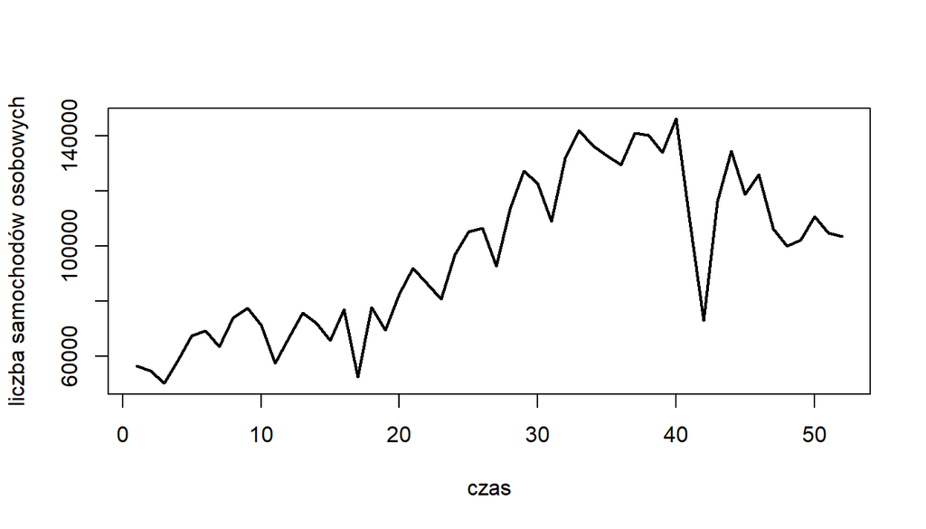

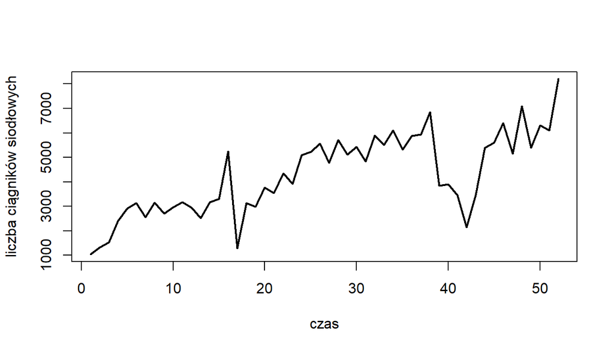

# 2. Identyfikacja nielosowych składowych

## 2.1. Trend

### 2.1.1. Samochody osobowe

Wybór stopnia wielomianu dla samochodów osobowych:

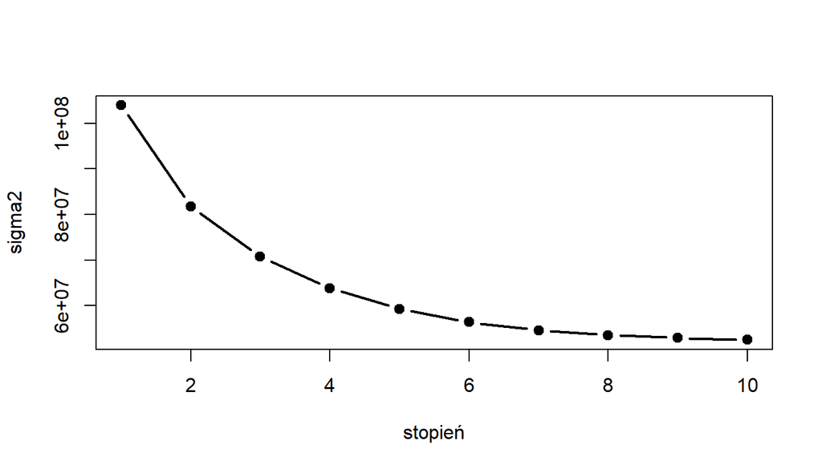

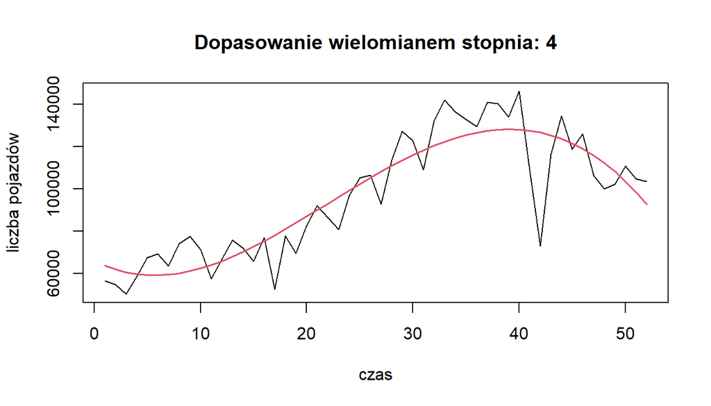

Wybieramy wielomian stopnia 4.

### 2.1.2. Ciągniki siodłowe

Wybór stopnia wielomianu dla ciągników siodłowych:

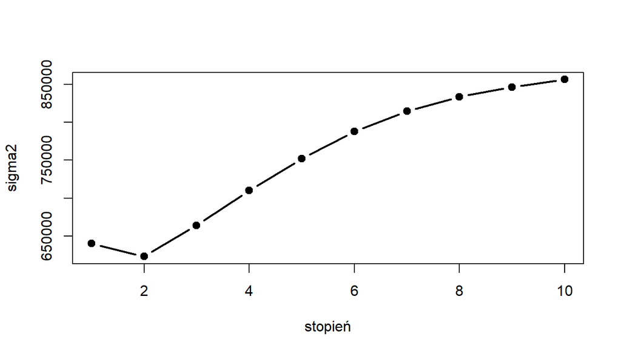

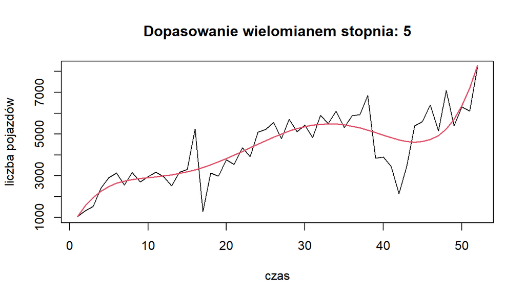

### 2.1.3. Zbudowanie modeli

## 2.2. Sezonowość

### 2.2.1 Samochody osobowe

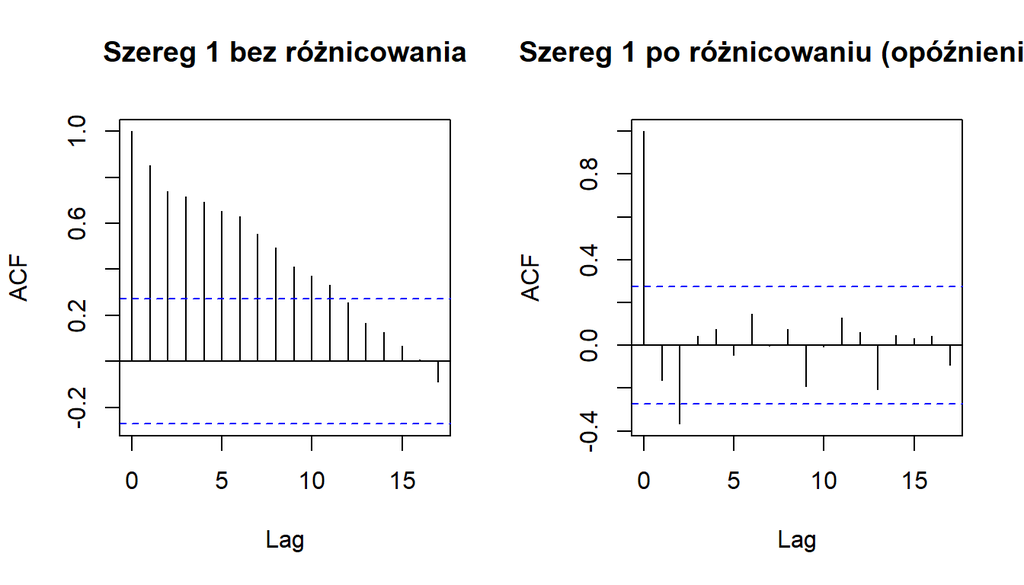

```
    Augmented Dickey-Fuller Test

data:  diff(X)
Dickey-Fuller = -4.948, Lag order = 3, p-value = 0.01
alternative hypothesis: stationary
```

```
    KPSS Test for Level Stationarity

data:  diff(X)
KPSS Level = 0.15348, Truncation lag parameter = 3, p-value = 0.1
```

Po różnicowaniu szereg liczby samochodów osobowych jest stacjonarny, ponieważ wyeliminowaliśmy lokalne trendy.

### 2.2.2 Ciągniki siodłowe

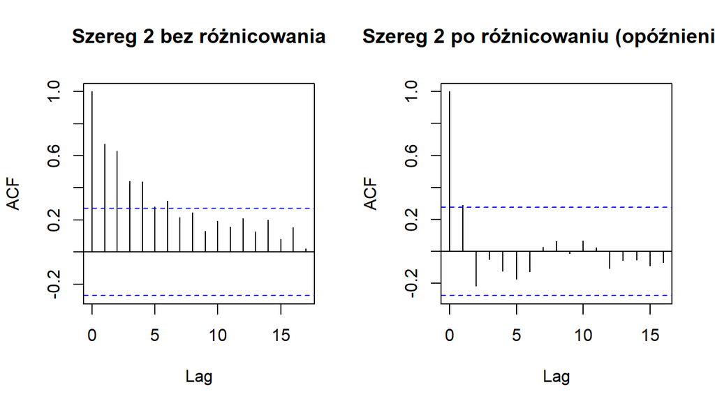

```
    Augmented Dickey-Fuller Test

data:  diff(Y)
Dickey-Fuller = -3.7075, Lag order = 3, p-value = 0.03271
alternative hypothesis: stationary
```

```
    KPSS Test for Level Stationarity

data:  diff(Y)
KPSS Level = 0.075118, Truncation lag parameter = 3, p-value = 0.1
```

Szereg liczby ciągników siodłowych jest, po różnicowaniu, również stacjonarny.

# 3. Identyfikacja (modelowanie) reszt

## 3.1. Korelacje

$H_0$: Błędy nie są skorelowane

$H_1$: Błędy są skorelowane

```
    Durbin-Watson test

data:  model
DW = 1.2675, p-value = 0.0003344
alternative hypothesis: true autocorrelation is greater than 0
```

Dla pierwszego modelu wartość $p$ jest mniejsza niż przyjęty poziom istotności $0.05$, zatem odrzucamy hipotezę zerową.

```
    Durbin-Watson test

data:  model2
DW = 1.6223, p-value = 0.01478
alternative hypothesis: true autocorrelation is greater than 0
```

Dla drugiego modelu również odrzucamy hipotezę o braku korelacji reszt.

## 3.2. Stacjonarność

Do zbadania stacjonarności szeregów użyjemy **rozszerzonego testu Dickey’a-Fullera** i **testu Kwiatkowskiego-Phillipsa-Schmidta-Shina**. Dla testu ADF formułujemy hipotezy:

$H_0$: Szereg czasowy jest niestacjonarny.

$H_1$: Szereg czasowy jest stacjonarny.

Natomiast dla testu KPSS:

$H_0$: Szereg czasowy jest stacjonarny

$H_1$: Szereg czasowy jest niestacjonarny

```
    Augmented Dickey-Fuller Test

data:  X
Dickey-Fuller = -1.0175, Lag order = 3, p-value = 0.9271
alternative hypothesis: stationary
```

```
    KPSS Test for Level Stationarity

data:  X
KPSS Level = 1.0592, Truncation lag parameter = 3, p-value = 0.01
```

```
    Augmented Dickey-Fuller Test

data:  Y
Dickey-Fuller = -2.5026, Lag order = 3, p-value = 0.3722
alternative hypothesis: stationary
```

```
    KPSS Test for Level Stationarity

data:  Y
KPSS Level = 1.0508, Truncation lag parameter = 3, p-value = 0.01
```

Na podstawie powyższych testów możemy stwierdzić, że oba szeregi nie są stacjonarne.

## 3.3. Homoskedastyczność

Użyjemy testu **Goldfielda-Quandta** do zbadania homoskedastyczności.

$H_0$: Wariancja każdego błędu w modelu jest taka sama.

$H_1$: Błędy mają różne wariancje

```
    Goldfeld-Quandt test

data:  model
GQ = 3.7084, df1 = 21, df2 = 21, p-value = 0.002042
alternative hypothesis: variance increases from segment 1 to 2
```

```
    Goldfeld-Quandt test

data:  model2
GQ = 2.1804, df1 = 20, df2 = 20, p-value = 0.04451
alternative hypothesis: variance increases from segment 1 to 2
```

Zarówno dla pierwszego jak i drugiego modelu odrzucamy hipotezę zerową na korzyść hipotezy alternatywnej. Oznacza to, że wariancje są niejednorodne.

## 3.4. GARCH

Dla obu szeregów czasowych zastosowaliśmy model z parametrami **(1,3)**, ponieważ przy przeszukiwaniu różnych parametrów, te okazały się mieć najmniejszy współczynnik AIC.

```
Call:
garch(x = X, order = c(1, 3))

Model:
GARCH(1,3)

Residuals:
   Min     1Q Median     3Q    Max
0.4392 0.7375 0.8124 0.8662 1.0299

Coefficient(s):
    Estimate  Std. Error  t value Pr(>|t|)
a0 6.437e+08          NA       NA       NA
a1 5.548e-01          NA       NA       NA
a2 5.180e-01          NA       NA       NA
a3 5.189e-01          NA       NA       NA
b1 1.266e-06          NA       NA       NA

Diagnostic Tests:
    Jarque Bera Test

data:  Residuals
X-squared = 9.0511, df = 2, p-value = 0.01083


    Box-Ljung test

data:  Squared.Residuals
X-squared = 1.4861, df = 1, p-value = 0.2228
```

Wartość $p$ w teście Jarque-Bera jest mniejsza niż $0.05$, zatem odrzucamy hipotezę o normalności rozkładu reszt.

Na podstawie testu Boxa-Ljunga nie mamy podstaw do odrzucenia hipotezy o braku autokorelacji.

```
Call:
garch(x = Y, order = c(1, 3))

Model:
GARCH(1,3)

Residuals:
   Min     1Q Median     3Q    Max
0.2425 0.6972 0.8110 0.9367 1.3091

Coefficient(s):
    Estimate  Std. Error  t value Pr(>|t|)
a0 2.178e+06          NA       NA       NA
a1 5.634e-01          NA       NA       NA
a2 5.343e-01          NA       NA       NA
a3 4.633e-01          NA       NA       NA
b1 2.208e-08          NA       NA       NA

Diagnostic Tests:
    Jarque Bera Test

data:  Residuals
X-squared = 1.7329, df = 2, p-value = 0.4204


    Box-Ljung test

data:  Squared.Residuals
X-squared = 0.73164, df = 1, p-value = 0.3924
```

Dla drugiego modelu wartość $p$ w teście Jarque-Bera jest większa niż przyjęty poziom istotności, zatem nie mamy podstaw do odrzucenia hipotezy o normalności rozkładu.

Na podstawie testu Boxa-Ljunga stwierdzamy, tak jak dla pierwszego modelu, że reszty nie są skorelowane.

# 4. SARIMA

```
Series: ts_data
ARIMA(0,1,2)

Coefficients:
          ma1      ma2
      -0.2171  -0.2799
s.e.   0.1327   0.1176

sigma^2 = 181186520:  log likelihood = -556.36
AIC=1118.72   AICc=1119.23   BIC=1124.51
```

```
Series: ts_data
ARIMA(0,1,2)(4,1,2)[4]

Coefficients:
          ma1      ma2    sar1     sar2     sar3     sar4     sma1    sma2
      -0.0718  -0.4801  0.7830  -0.0029  -0.1928  -0.1097  -1.9648  0.9846
s.e.   0.1454   0.1693  0.4681   0.1839   0.2276   0.2397   1.2936  1.2970

sigma^2 = 137584358:  log likelihood = -514.48
AIC=1046.97   AICc=1051.83   BIC=1063.62

Training set error measures:
                    ME     RMSE      MAE      MPE     MAPE      MASE
Training set -1414.245 10158.16 6298.331 -2.13377 6.996225 0.4335062
                    ACF1
Training set -0.09615871
```

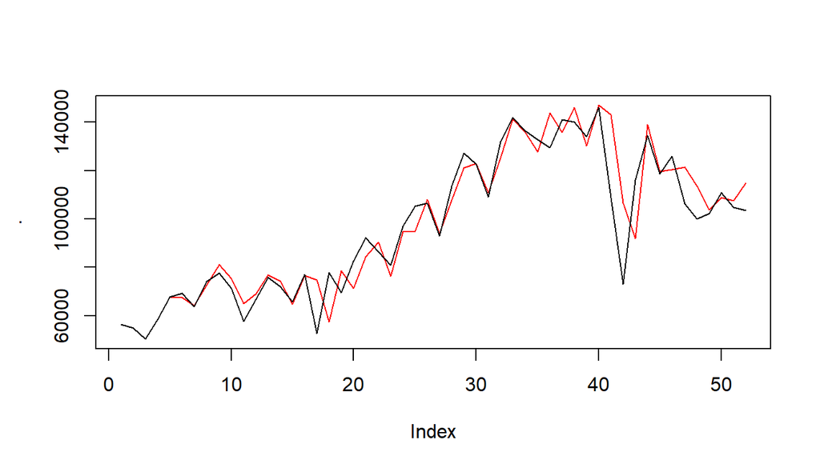

```
Series: ts_data2
ARIMA(1,1,0)

Coefficients:
          ar1
      -0.4911
s.e.   0.1250

sigma^2 = 1e+06:  log likelihood = -424.29
AIC=852.59   AICc=852.84   BIC=856.45
```

W drugim przypadku używamy parametrów dla składowych niesezonowych $(1,1,0)$. Parametry sezonowe pozostają bez zmian.

```
Series: ts_data2
ARIMA(1,1,0)(4,1,2)[4]

Coefficients:
          ar1    sar1    sar2     sar3     sar4     sma1    sma2
      -0.2697  0.7805  0.0613  -0.1734  -0.0563  -1.9214  0.9935
s.e.   0.1463  0.2455  0.2259   0.2055   0.3097   1.0069  1.0272

sigma^2 = 846209:  log likelihood = -390.58
AIC=797.16   AICc=800.95   BIC=811.96

Training set error measures:
                    ME     RMSE      MAE       MPE     MAPE      MASE
Training set -59.04279 806.8021 538.5454 -6.456574 16.20475 0.5109741
                    ACF1
Training set -0.03740173
```

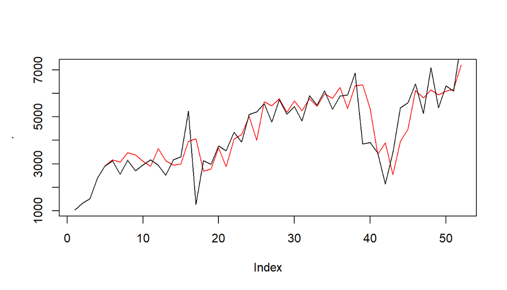

# 5. Holt-Winters

## 5.1 Samochody osobowe

```
Holt-Winters exponential smoothing with trend and multiplicative seasonal component.

Call:
HoltWinters(x = ts_data, seasonal = "multiplicative")

Smoothing parameters:
 alpha: 0.7137117
 beta : 0.03224566
 gamma: 0.3049768

Coefficients:
           [,1]
a  1.079146e+05
b  1.041016e+03
s1 9.892742e-01
s2 9.840274e-01
s3 9.219543e-01
s4 9.765842e-01
```

Parametr $alpha$ informuje nas o tym, jak duży wpływ na zmianę szeregu czasowego mają bieżące obserwacje. Jest on równy $0.71$, co świadczy o tym, że ten wpływ jest duży.

Na podstawie parametru $beta$ równego $0.03$ możemy stwierdzić, że ostatnie obserwacje mają bardzo mały wpływ na zmianę trendu.

Parametr $gamma$ wynosi $0.3$, co oznacza że ostatnie obserwacje mają mały wpływ na zmiany wzorców sezonowych.

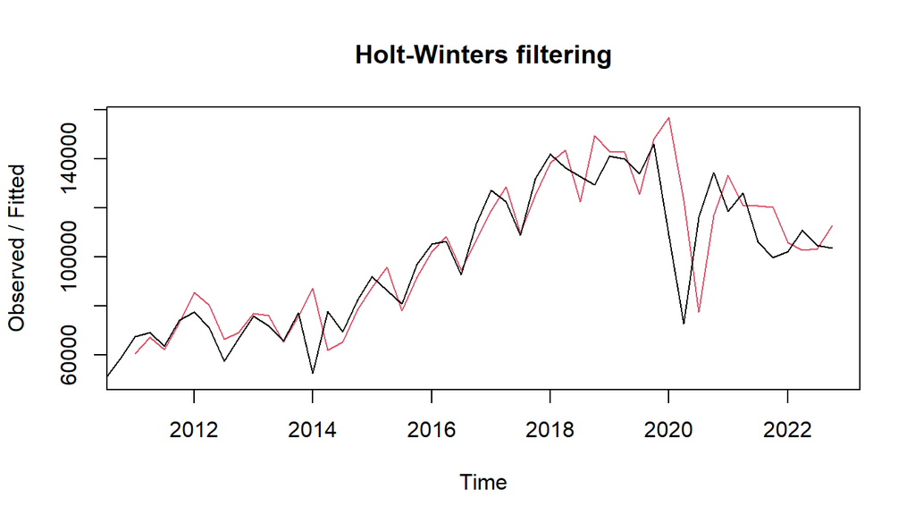

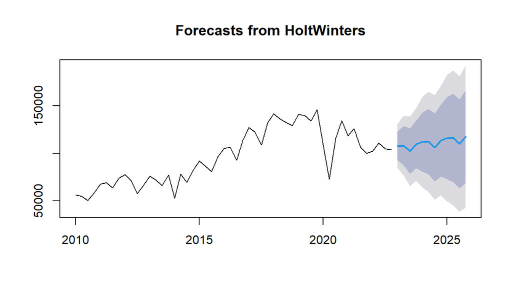

Przez ostatnie spadki i stabilizacje w danych, przedział ufności dla przyszłych danych jest szerszy, zakładając zarówno mocny spadek jak i wzrost w sprzedaży aut osobowych.

Dla porównania poniżej przedstawiamy ten sam model, jednak dla danych bez ostatnich 5 lat (do 2018 roku):

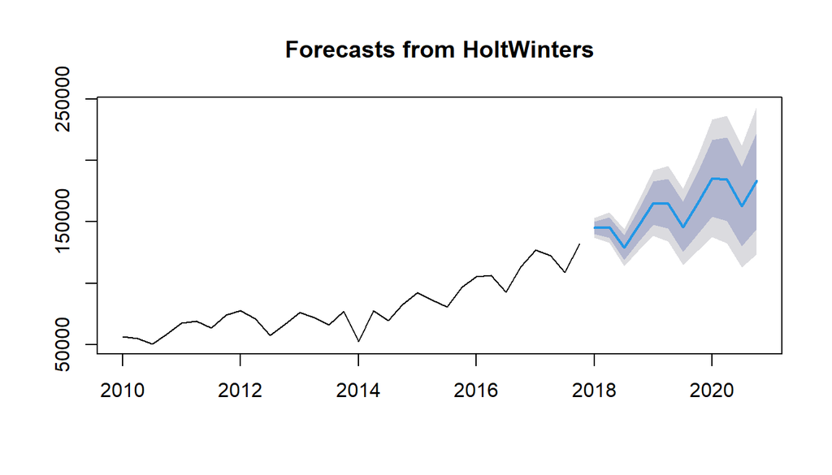

Widać wyraźnie, że model przewiduje wzrost danych, zachowując przy tym sezonowe spadki.

Teraz pokażemy wykres reszt dla modelu Holt-Winters i korelogram reszt.

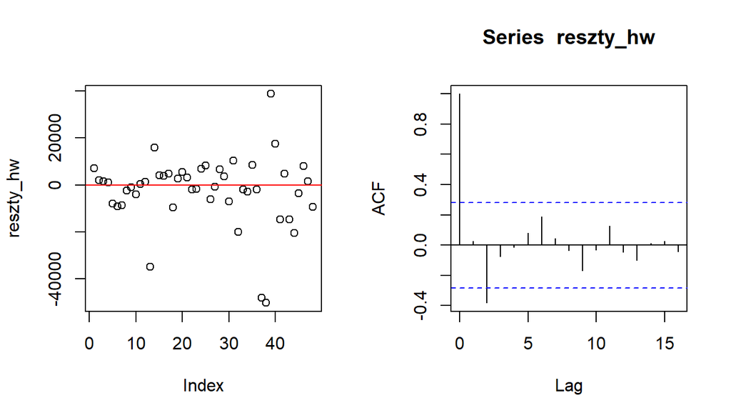

Linie przerywane reprezentują przedziały ufności dla autokorelacji. Wartości przekraczające te przedziały sugerują istotne korelacje.

## 5.2 Ciągniki siodłowe

```
Holt-Winters exponential smoothing with trend and multiplicative seasonal component.

Call:
HoltWinters(x = ts_data2, seasonal = "multiplicative")

Smoothing parameters:
 alpha: 0.7260936
 beta : 0.04199913
 gamma: 0.1959948

Coefficients:
           [,1]
a  7805.5256524
b   176.3652696
s1    0.9362797
s2    1.0217929
s3    0.8560945
s4    1.0227962
```

Tak jak w przypadku samochodów osobowych, bieżące obserwacje mają duży wpływ na zmianę szeregu czasowego $(alpha=0.73)$, ostatnie obserwacje mają bardzo mały wpływ na zmianę trendu $(beta=0.04)$ oraz mają one mały wpływ na zmiany wzorców sezonowych $(gamma=0.2)$.

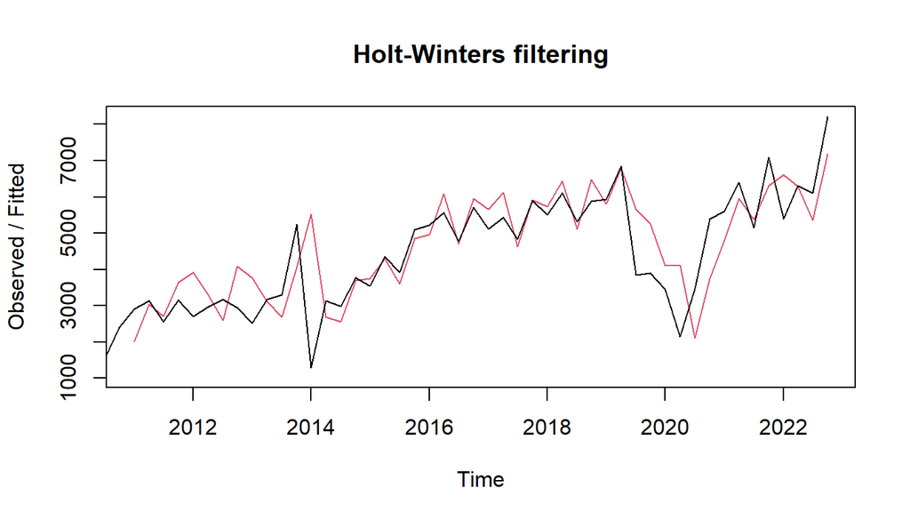

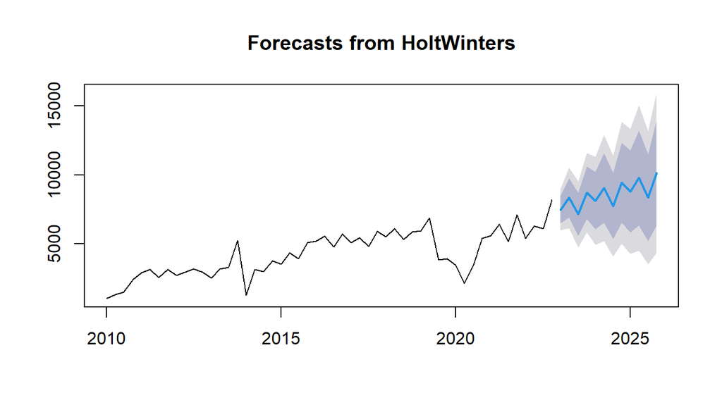

Przedziały ufności mają duże zakresy. Wyniki prognoz wskazują na tendencję wzrostową liczby ciągników siodłowych.

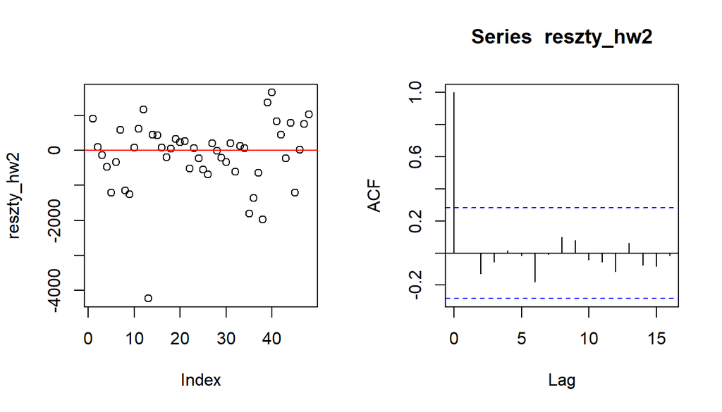